# Analysing metabarcoding data using dada2

Nicolas Henry

nicolas.henry@cnrs.fr

Charlotte Berthelier

cberthelier@sb-roscoff.fr

September 29, 2026

# Introduction

## Metabarcoding at the lab

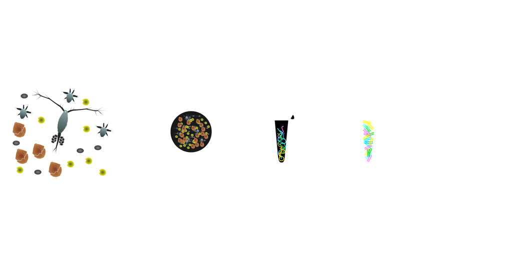

## Sequencing generations

[figure not shown]

## Paired-end sequencing

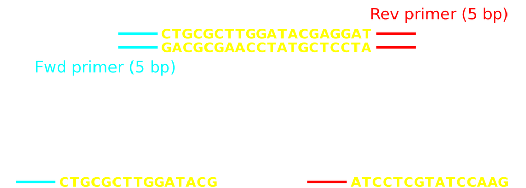

Short reads: from 2*150 bp to 2*300 bp, often 2*250 bp

## Next steps until an ASV table

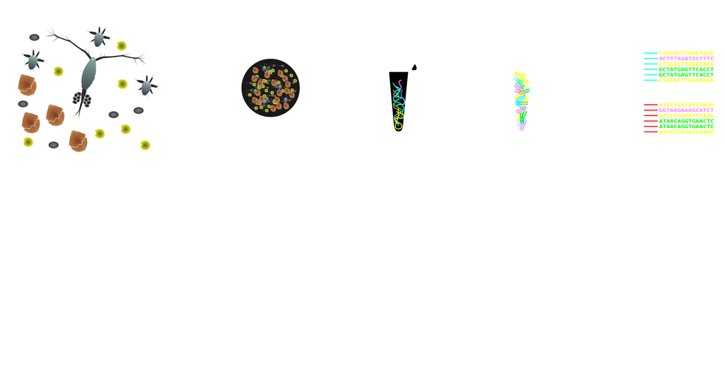

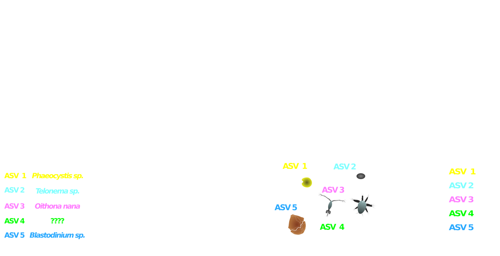

## Many markers for metabarcoding

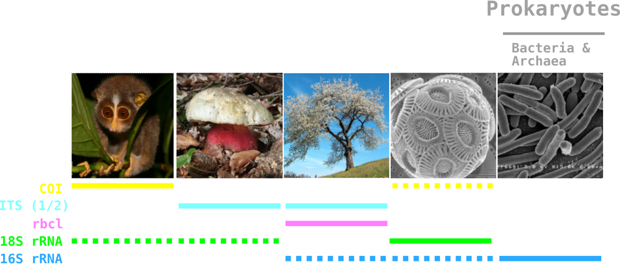

# FASTQ records

## Overview

Two files (R1 and R2) per sequencing run or per sample (100 first nucleotides):

R1:

```
@M01522:260:000000000-C3YFC:1:2114:21886:9214 1:N:0:CTTGTA
CCTACGGGGGGCAGCAGTAGGGAATTTTGCGCAATGGGCGAAAGCCTGACGCAGCAACGCCGCGTGATCGATGAAGCTTCTAGGAGCGTAAAGATCTGTC
+
GGGGGGGGGGGGGGGGGGGGGGGGGGGGGGGGGGGGGGGGGGGGGGGGGGGGEGGFGGGGGGGGGGGGGGFGGGFGGGGGGGGGGGGGGGGGGGGGGGGG
```

R2:

```
@M01522:260:000000000-C3YFC:1:2114:21886:9214 2:N:0:CTTGTA
GACTACCAGGGTATCTAATCCTGTTCGCTCCCCACGCTTTCGTCCCTCAGCGTCAGTTTTAGGCCAGAAAGTTGCCTTCGCCATTGGTGTTCCTTCTGAT
+
CCCCCFGGGGGGGGGGGGGGGGGGGCEGGGGGGGGGGEEEFGG>GGGGGGGGGGGGFGGGG?FGGGGGFGFGGFGGFGGCGEGGGGGGGG>FGGGGGGGG
```

Per record: identifier, sequence, quality

## Identifier

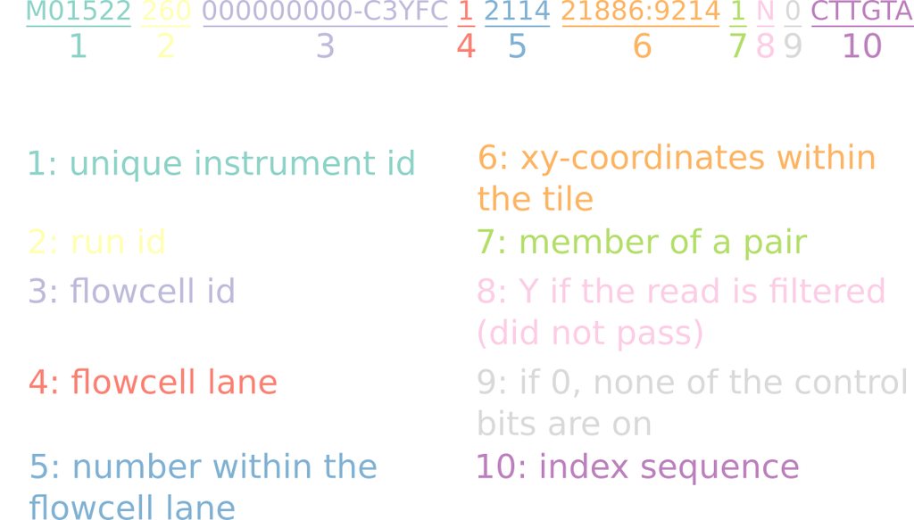

## Sequence

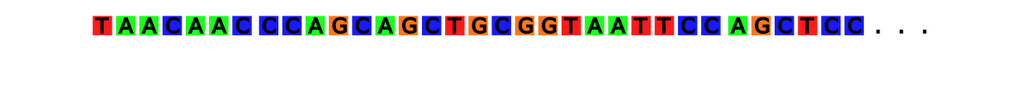

- The tag informs you from which sample the read come from
- The primer used for the amplification
- The targeted sequence (metabarcode)

## Quality

Phred quality score (Q) encoded using ASCII characters:

$Q$ is related to the base calling error probability ($P$):

$$Q = -10\log_{10}P$$

$$P=10^{Q/-10}$$

# Bioinformatic pipelines

## Main strategies

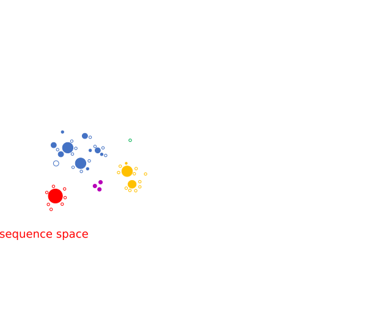

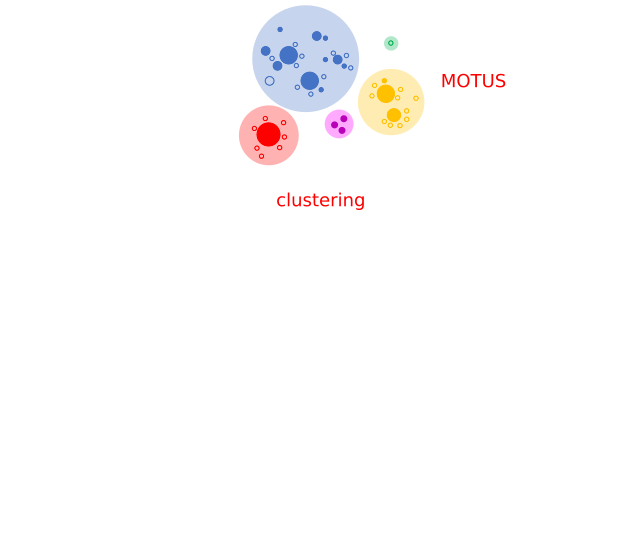

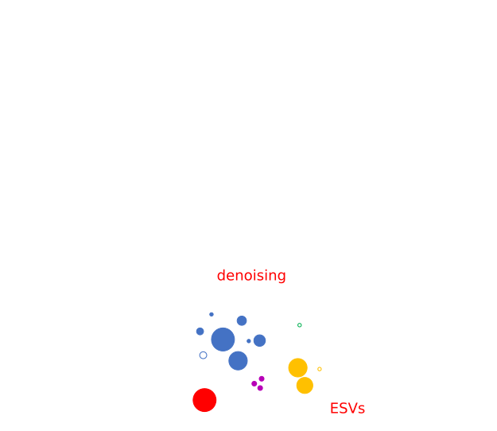

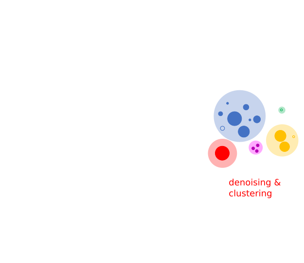

Adapted from (Antich et al. 2021): By combining **denoising** and **clustering** approaches, it allows to **better capture the natural variability of the COI gene** while reducing errors introduced during sequencing and analysis.

## Many tools

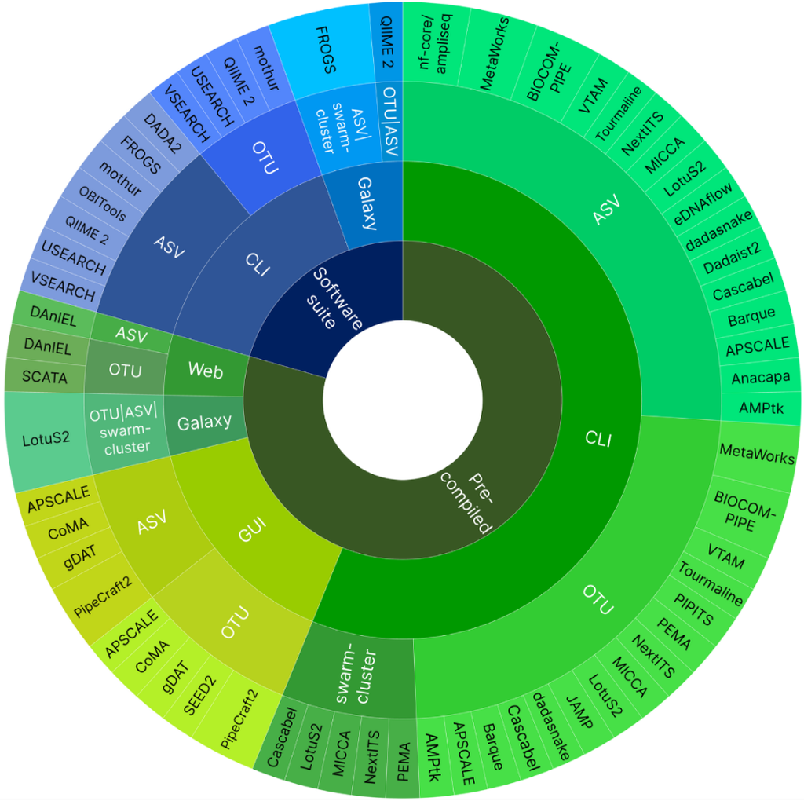

Extracted from (Hakimzadeh et al. 2023)

## Workflow manager

[Nextflow](https://www.nextflow.io/index.html) and [Snakemake](https://snakemake.github.io/) are the most popular

[figure not shown]

## DADA2, qu’est-ce que c’est?

- DADA (Divisive Amplicon Denoising Algorithm) an algorithm to denoise Roche’s 454 platform errors (Rosen et al. 2012)
- DADA2 implements a new quality-aware model of Illumina amplicon errors (Callahan et al. 2016)
- DADA2 is an open-source R package https://github.com/benjjneb/dada2

## DADA2, the full workflow

- Quality assessment → `plotQualityProfile()`
- Length trimming → `filterAndTrim()`
- Quality filtering → `filterAndTrim()`
- Denoising → `dada()`
- Merging pair-end reads → `mergePairs()`
- Chimera identification → `removeBimeraDenovo()`
- Taxonomic assignment → `assignTaxonomy()`

# Before using Dada2

## Tags and primers

**Tags** are used to encode the sample provenance of the reads. Reads need to be grouped by sample provenance (`demultiplexing`).

**Primer** sequences will bias the error model built by DADA2 and need to be removed (`primer trimming`).

`Demultiplexing` and `primer trimming` : Both task can be achieved using **Cutadapt**, a command line-tool to find and remove error-tolerantly adapters from reads (Martin 2011).

## Demultiplexing using cutadapt

If your tags are in a fasta file with corresponding sample names as header, you can use this command-line:

```bash
cutadapt \
    -g file:${BARCODES} \
    -o {name}_R1.fastq.gz \
    -p {name}_R2.fastq.gz \
    ${R1_FILE} \
    ${R2_FILE}
```

```bash
#
# tags to look for at the beginning (5') of R1 files. ${BARCODES} is a fasta file containing the tags
# demultiplexed R1 file output. name will be replace by the name of the tag
# same as above but with R2 files
# input R1 file
# input R2 file
```

As many R1 and R2 files as samples you have

## Primer removal using cutadapt

To remove forward and reverse primer sequences from pair-end read files:

```bash
cutadapt \
    -e 0.1 \
    -g ${PRIMER_FORWARD} \
    -G ${PRIMER_REVERSE} \
    --report=minimal \
    --discard-untrimmed \
    --minimum-length ${MIN_LENGTH} \
    --no-indels \
    -o ${FORWARD} \
    -p ${REVERSE} \
    ${R1_FILE} \
    ${R2_FILE} 1> ${LOG}
```

```bash
#
# error tolerance (default value)
# forward primer
# reverse primer
# ask to print primer trimming statistics
# reads not containing primers are discarded
# read with a length below this threshold after trimming are discarded
# no indels allowed when mathing primer to reads
# R1 output
# R2 output
# R1 input
# R2 input; 1> ${LOG} export the report in the file ${LOG}
```

As for demultiplexing, if reads are mix-orientated, run `cutadapt` twice.

# DADA2 workflow: reads preparation

## Check reads quality

Check the overall quality of a sequencing run using `plotQualityProfile()`

Outside of DADA2, you can also use [FASTQC](https://github.com/s-andrews/FastQC)

If the overall quality is too low, you will probably have to resequence your samples

[figure not shown]

A quality drop is often observed in the end of the reads

## Trimming and filtering

Trimming, at a given length, will improve the overall read quality

**Danger zone**

After trimming, make sure that forward and reverse reads are still long enough to overlap

Reads of low quality and/or with ambiguous nucleotides (N) after trimming are filtered out.

Both length trimming and quality filtering are achieved using the function `filterAndTrim()`

# DADA2 workflow: denoising approach

## Denoising

Is sequence $i$ generated by sequence $j$ because of sequencing errors?

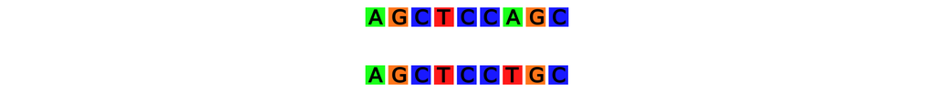

In order to define if $i$ is an error of $j$ and perform denoising using DADA2, we need to compute:

- the error rate $\lambda_{ji}$
- the abundance p-value $p_A(j \rightarrow i)$

## Error rate

> The rate at which an amplicon read with sequence i is produced from sample sequence j is reduced to the product over the transition probabilities between the L aligned nucleotides:

$$\lambda_{ji} = \prod_{l=0}^L p(j(l) \rightarrow i(l),q_i(l))$$

## The abundance p-value

The abundance p-value ($p_A$) is the probability of all reads of $i$ ($a_i$) or more being produced from $j$ during amplification or sequencing.

$$p_A(j \rightarrow i) = \frac{1}{1- \rho_{\mathrm{pois}}(n_j\lambda_{ji},0)} \sum_{a=a_i}^\infty \rho_{\mathrm{pois}}(n_j\lambda_{ji},a)$$

A low p-value indicate that it is unlikely that $i$ is noise from amplifying and sequencing $j$

## The divisive partitioning algorithm: step 1

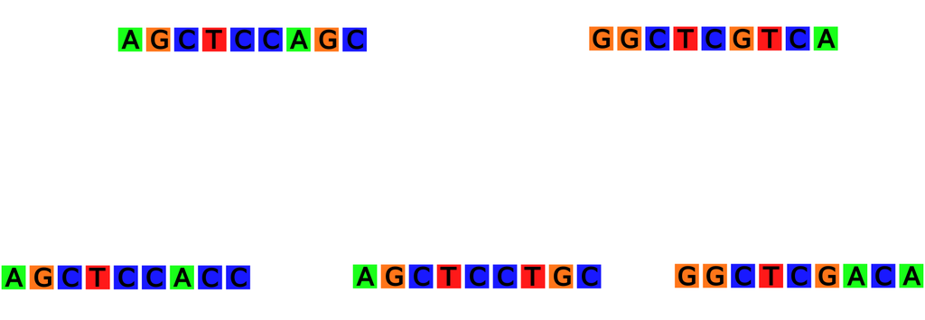

## The divisive partitioning algorithm: step 2

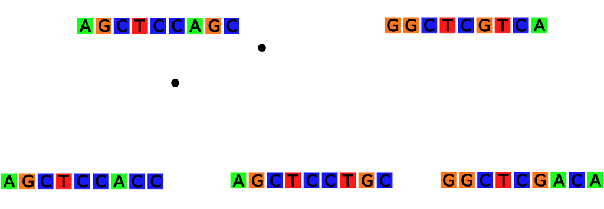

$p_A$ of all sequences against most abundant sequence (center)

## The divisive partitioning algorithm: step 3

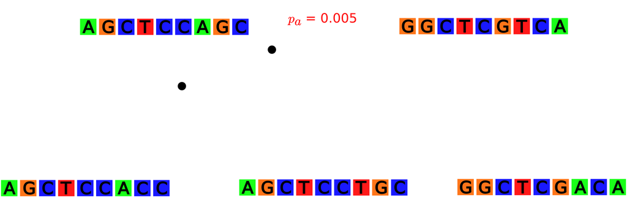

if smallest p-value below $\Omega_A$: new partition

## The divisive partitioning algorithm: step 4

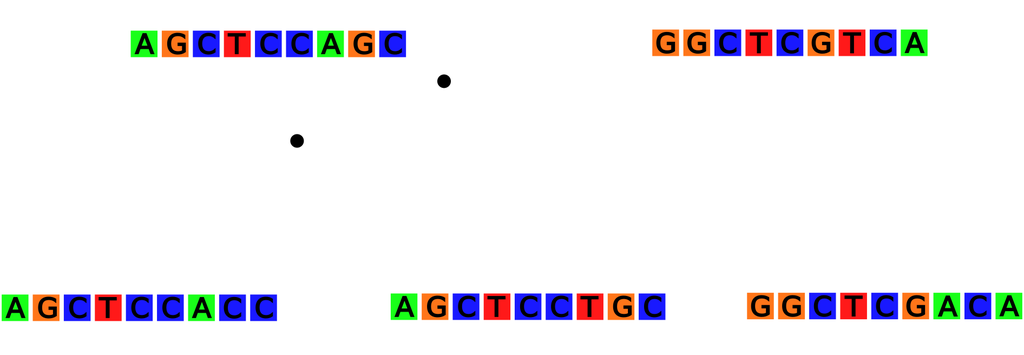

$p_A$ of all sequences against center of new partition

## The divisive partitioning algorithm: step 5

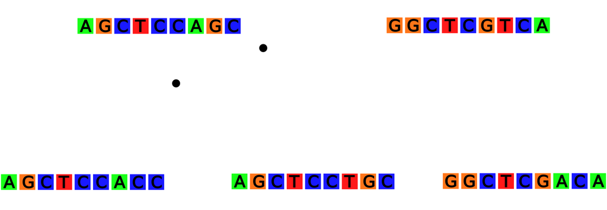

Every sequence join the partition most likely to have produced it. Repeat steps 3 to 5 until all abundance p-values are greater than $\Omega_A$

# DADA2 workflow: denoising in practice

## Learn the error model

How do we compute $\lambda_{ji}$ if we don’t know the error rate for each possible transition?

The error rates will be learned from the data using `learnErrors()`

> The learnErrors method learns this error model from the data, by alternating estimation of the error rates and inference of sample composition until they converge on a jointly consistent solution

## Visualise the error model

You can visualise the estimated error rates using the function `plotErrors()`

[figure not shown]

## Run the DADA2 algorithm

- After dereplicating your sequences (`derepFastq()`), denoise using the function `dada()`
- By default sample inference is performed on each sample individually (`pool = FALSE`).
- If you are interested in rare variants present in several samples use `pool = TRUE`
- When working on big data, `pool = "pseudo"` is an interesting alternative to `pool = TRUE`

# DADA2 workflow: build the ASV table

## Merge paired reads

Merge forward and reverse reads using `mergePairs()`

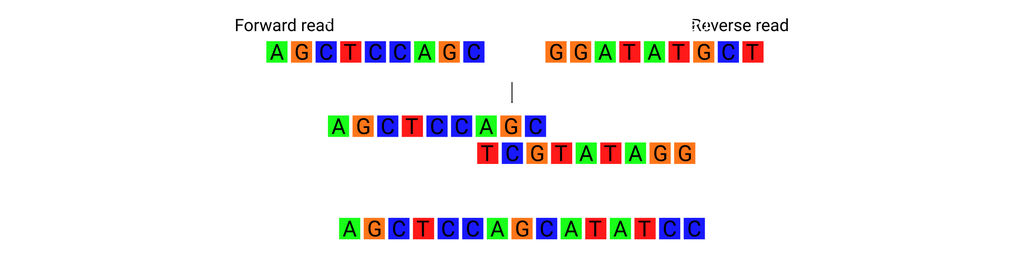

- `minOverlap`: minimum size of overlap
- `maxMismatch`: maximum number of mismatches
- `justConcatenate`: in case your reads don’t overlap

## Chimeras

Chimeric sequences are identified if they can be exactly reconstructed by combining a left-segment and a right-segment from two more abundant “parent” sequences.

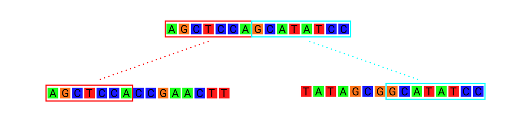

Find and remove bimeras (two-parent chimeras) using the function `removeBimeraDenovo()`, per sample (`method="per-sample"`), for the entire dataset (`method="pooled"`) or in a consensus way (`method="consensus"`)

# Assign taxonomy

## Reference sequence database

Make the link in between nucleic sequences and taxonomic

Broad reference database: [GenBank](https://www.ncbi.nlm.nih.gov/genbank/)

- Some specialised references databases:
  - [Silva](https://www.arb-silva.de/) (16S rRNA (bacteria and archaea))
  - [PR2](https://pr2-database.org/) (18S eukaryotes and 16S Chloroplastes)
  - [MIDORI2](https://www.reference-midori.info/) (mitochondrial DNA)
  - [BOLD / Barcode Of Life Data](https://boldsystems.org/) (COI / ITS / rbcL & matK)
  - [UNITE](https://unite.ut.ee/) (ITS 🍄)

## Classifiers (machine learning)

- Sequence taxonomic classification based on k-mers composition.
- No sequence similarity threshold but a confidence score instead.
- RDP classifier (naïve Bayes method) is very popular, give good results at least for 16S/18S.
- IDTAXA, more recent, would tend to less overclassify.

DADA2 function `assignTaxonomy()` use a native implementation of the naïve Bayesian classifier method ([Wang et al. 2007](https://doi.org/10.1128/aem.00062-07)).

## BLAST like approaches

Looking for the closest reference sequences to inherit their taxonomy

Best hits or LCA approaches

Recommand global alignment (usearch_global [VSEARCH](https://github.com/torognes/vsearch) command) with specialised reference database

```bash
vsearch \
  --usearch_global ${INPUT} \
  -db ${REFDB} \
  --id 0.80 \
  --maxaccepts 0 \
  --top_hits_only \
  --userout ${TMP} \
  --userfields "query+id1+target"
```

```bash
#
# sequences to assign fasta file
# reference database reference database
# lower similarity threshold
# maximum hits (0 = unlimited)
# keep only best hits
# output file
# fields to export
```

# Extra steps

## Phylogenetic placement

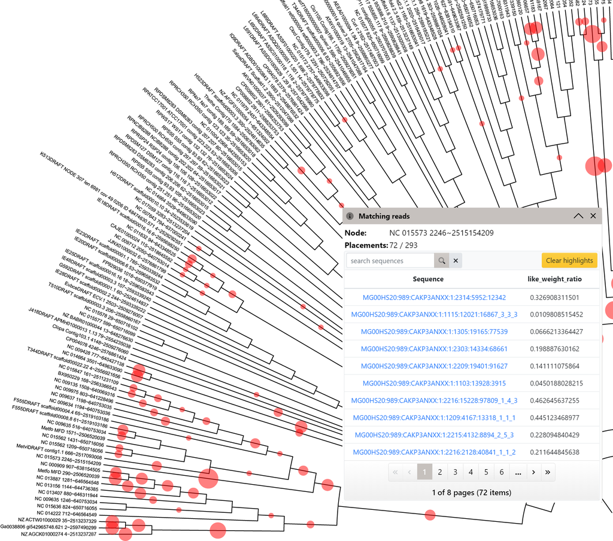

Figure from https://itol.embl.de/

## Post-clustering with LULU

Abundance aware clustering:

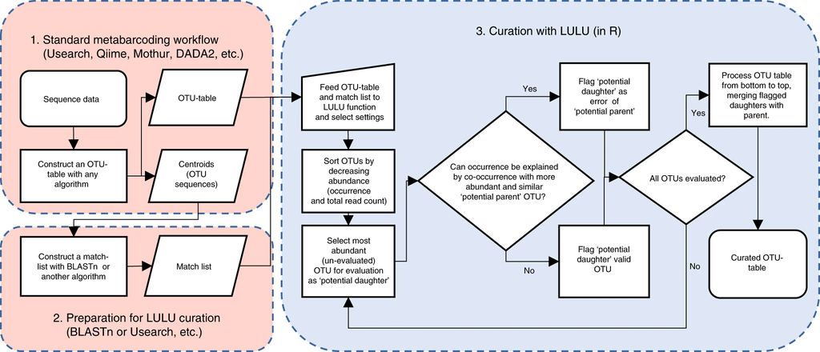

Figure from (Frøslev et al. 2017). For a C++ implementation, have a look at [MUMU](https://github.com/frederic-mahe/mumu)

## Decontamination

Frequency-based contaminant identification with the R package decontam:

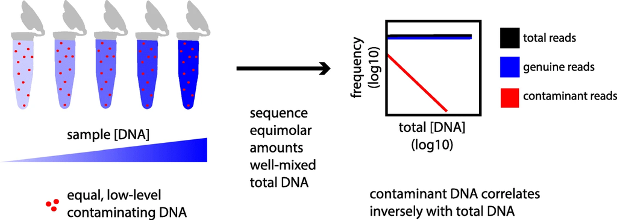

Decontamination can also be achieved with the R package metabaR and the function `contaslayer()`

# Now it is your turn!

# References

Antich, Adrià, Creu Palacin, Owen S Wangensteen, and Xavier Turon. 2021. “To Denoise or to Cluster, That Is Not the Question: Optimizing Pipelines for COI Metabarcoding and Metaphylogeography.” *BMC Bioinformatics* 22: 1–24.

Callahan, Benjamin J, Paul J McMurdie, Michael J Rosen, Andrew W Han, Amy Jo A Johnson, and Susan P Holmes. 2016. “DADA2: High-Resolution Sample Inference from Illumina Amplicon Data.” *Nature Methods* 13 (7): 581–83.

Frøslev, Tobias Guldberg, Rasmus Kjøller, Hans Henrik Bruun, et al. 2017. “Algorithm for Post-Clustering Curation of DNA Amplicon Data Yields Reliable Biodiversity Estimates.” *Nature Communications* 8 (1): 1188.

Hakimzadeh, Ali, Alejandro Abdala Asbun, Davide Albanese, et al. 2023. “A Pile of Pipelines: An Overview of the Bioinformatics Software for Metabarcoding Data Analyses.” *Molecular Ecology Resources*.

Martin, Marcel. 2011. “Cutadapt Removes Adapter Sequences from High-Throughput Sequencing Reads.” *EMBnet. Journal* 17 (1): 10–12.

Rosen, Michael J, Benjamin J Callahan, Daniel S Fisher, and Susan P Holmes. 2012. “Denoising PCR-Amplified Metagenome Data.” *BMC Bioinformatics* 13 (1): 1–16.